# Third Week: Exploratory Data Analysis

LaLiga Analysis

Tara Boroushaki 93105501

2018-02-27 21:44:48

# تمرین سری سوم: از لالیگا تا لیگ برتر

> با استفاده از داده های لیگ دسته اول اسپانیا به سوالات زیر پاسخ دهید. از هر دو ابزار ggplot2 و highcharter برای این کار تصویرسازی استفاده نمایید.

۱. تعداد قهرمانی های تیم ها در تاریخ لالیگا را استخراج کرده و نمودار ستونی آنها را رسم کنید.

```r
#1

rbind(
  fdb%>%
    select(Season,Team=home,Opponent=visitor,Gt=hgoal,Go=vgoal),
  fdb%>%
    select(Season,Team=visitor,Opponent=home,Gt=vgoal,Go=hgoal)
  )%>%
  mutate(Gdif=Gt-Go)%>%
  group_by(Season,Team)%>%
  summarize(goalsTeam = sum(Gt),
            goalsOpp = sum(Go),
            goaldif = sum(Gdif),
            W = sum(Gdif>0),
            eq = sum(Gdif==0),
            L = sum(Gdif<0)
  ) %>%
  mutate(score = W*3 + eq) %>%
  arrange(Season,desc(score),desc(goaldif)) %>%
  group_by(Season) ->Seasontable

champNum=Seasontable%>%group_by(Season)%>%
      summarize(Team=Team[which.max(score)[1]],Score=score[which.max(score)[1]])%>%
      group_by(Team)%>%summarize(num=n())

champNum%>%hchart(type = "bar",hcaes(x = Team, y = num),name = "champion cups")%>%hc_title(text = "champion cups")->p1
p1
```

[interactive chart not shown]

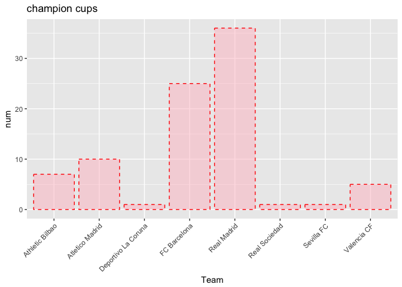

```r
p1_=ggplot(champNum,aes(x=Team,y=num))+geom_col(linetype = "dashed",color = "red",fill = "pink",alpha=0.5)+
  xlab("Team")+ylab("num")+ggtitle("champion cups")+theme(axis.text.x = element_text(angle = 45, hjust = 1, vjust = 1))
p1_
```

۲. کسل کننده ترین لیگ و تیم را بیابید. نمودار ده تیم و ده فصل کسل کننده را رسم کنید.

هر چه تعداد تساوی ها بیشتر باشد، کسل کننده تر است.

```r
rbind(
  fdb%>%
    select(Season,Team=home,Opponent=visitor,Gt=hgoal,Go=vgoal),
  fdb%>%
    select(Season,Team=visitor,Opponent=home,Gt=vgoal,Go=hgoal)
  )%>%
  mutate(Gdif=Gt-Go)%>%
  group_by(Team)%>%
  summarize(Gn=n(),
            goalsTeam = sum(Gt),
            eq = sum(Gdif==0),

  ) %>% mutate(eqPercent=eq/Gn) %>%
  arrange(desc(eqPercent)) %>%
  .[1:10,]->keselTeam

keselTeam%>%
  select(Team=Team,boringness=eqPercent)%>%
  hchart(type = "bar",hcaes(x = Team, y = boringness),name = "")%>%hc_title(text = "boring Teams")->p2
p2
```

[interactive chart not shown]

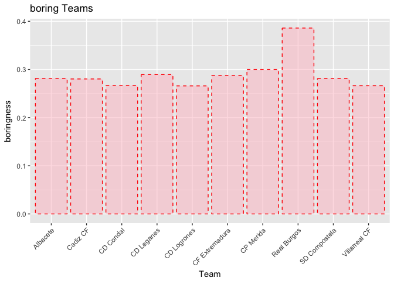

```r
p2_=ggplot(keselTeam,aes(x=Team,y=eqPercent))+geom_col(linetype = "dashed",color = "red",fill = "pink",alpha=0.5)+
  xlab("Team")+ylab("boringness")+ggtitle("boring Teams")+theme(axis.text.x = element_text(angle = 45, hjust = 1, vjust = 1))
p2_
```

```r
rbind(
  fdb%>%
    select(Season,Team=home,Opponent=visitor,Gt=hgoal,Go=vgoal),
  fdb%>%
    select(Season,Team=visitor,Opponent=home,Gt=vgoal,Go=hgoal)
) %>% mutate(Gdif=Gt-Go)%>%
  group_by(Season,Team)%>%
  summarize(Gn=n(),
            eq = sum(Gdif==0)
  ) %>%group_by(Season)%>%
  summarize(GnS=sum(Gn),
            eqS = sum(eq)
  )%>% mutate(eqPercent=eqS/GnS) %>%
  arrange(desc(eqPercent)) %>%
  .[1:10,]->keselSeason

keselSeason%>%
  mutate(Season1=as.character(Season))%>%
  select(Season=Season1,boringness=eqPercent)%>%
  hchart(type = "bar",hcaes(x =Season, y = boringness),name = "")%>%hc_title(text = "boring season")->p2_2
p2_2
```

[interactive chart not shown]

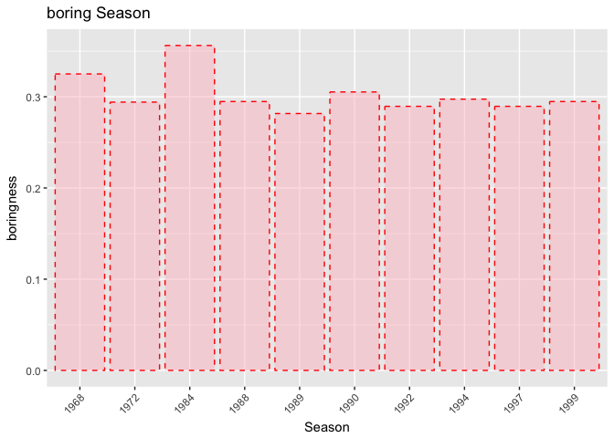

```r
p2_3=ggplot(keselSeason,aes(x=as.character(Season),y=eqPercent))+geom_col(linetype = "dashed",color = "red",fill = "pink",alpha=0.5)+
  xlab("Season")+ylab("boringness")+ggtitle("boring Season")+theme(axis.text.x = element_text(angle = 45, hjust = 1, vjust = 1))
p2_3
```

۳. در چند درصد موارد قهرمان نیم فصل در پایان فصل قهرمان شده است؟

```r
#3


rbind(
  fdb%>%
    select(Date,Season,Team=home,Opponent=visitor,Gt=hgoal,Go=vgoal),
  fdb%>%
    select(Date,Season,Team=visitor,Opponent=home,Gt=vgoal,Go=hgoal)
)%>%mutate(Gdif=Gt-Go)%>%
  mutate(W = ifelse(Gdif > 0,1,0),
        eq = ifelse(Gdif == 0,1,0),
        L =  ifelse(Gdif < 0,1,0)
  )%>%group_by(Season,Team)%>%
  arrange(Season,Date)%>%
  mutate(GameTillNow=row_number(Date))%>%
  group_by(Season,Team)%>%
  mutate(goalsTeamTillNow = cumsum(Gt),
         goalsAppTillNow  = cumsum(Go),
         goalDifTillNow  = cumsum(Gdif),
         WonTillNow  = cumsum(W),
         eqTillNow  = cumsum(eq),
         LostTillNow  = cumsum(L)
  ) %>%
  mutate(scoreTillNow  = WonTillNow *3 + eqTillNow ) ->laliga_half


laliga_half%>% group_by(Season) %>%
  filter(GameTillNow == max(GameTillNow)/2) %>%
  group_by(Season) %>%
  arrange(Season,desc(scoreTillNow),desc(goalDifTillNow)) ->laliga_half2

laliga_half2%>%group_by(Season)%>%
  summarize(Team=Team[which.max(scoreTillNow)[1]],Score=scoreTillNow[which.max(scoreTillNow)[1]])->halfChamp

champ=Seasontable%>%group_by(Season)%>%
  summarize(Team=Team[which.max(score)[1]],Score=score[which.max(score)[1]])%>%
  group_by(Team)

pp=sum(champ$Team==halfChamp$Team)/length(halfChamp$Team)
writeLines(as.character(cat("halfSeason champ becomes Seasons champ in  ",pp)), con = stdout(), sep = "\n", useBytes = FALSE)
```

```
## halfSeason champ becomes Seasons champ in   0.5348837
```

۴. در بین سال های ۲۰۰۱ تا ۲۰۱۰ گربه سیاه تیم های بزرگ چه تیم هایی بوده است؟

تیم هایی که “Real Madrid”,“FC Barcelona”,“Valencia CF”,“Atletico Madrid” را شکست بدهند و اختلاف گل هم بیشتر از ۱ باشد و جز تیم های قوی که شامل Real Madrid“,”FC Barcelona“,”Valencia CF“,”Atletico Madrid“,”Sevilla FC" نباشند، را گربه سیاه به حساب آوردم.

```r
# 4


bestTeams=c("Real Madrid","FC Barcelona","Valencia CF","Atletico Madrid")
rbind(
  fdb%>%
    select(Date,Season,Team=home,Opponent=visitor,Gt=hgoal,Go=vgoal),
  fdb%>%
    select(Date,Season,Team=visitor,Opponent=home,Gt=vgoal,Go=hgoal)
)%>%mutate(Gdif=Gt-Go)%>%filter(Season>2000)%>%filter(Season<2011)%>%
  filter(Team==bestTeams[1]|Team==bestTeams[2]|Team==bestTeams[3]|Team==bestTeams[4] )%>%
  filter((Opponent!=bestTeams[1]&Opponent!=bestTeams[2]&Opponent!=bestTeams[3]&Opponent!=bestTeams[4]&Opponent!="Sevilla FC"))%>%
  filter(Gdif<(-1))->a
a%>%group_by(Opponent)%>%summarise(numb=n())%>%arrange(numb)->a
a%>%hchart(type = "bar",hcaes(x =Opponent, y = numb),name = "")%>%
  hc_title(text = "black cat") %>% hc_yAxis(title = list(text = "# of defeating a big Team")) %>%
  hc_xAxis(title = list(text = "Team"))
```

[interactive chart not shown]

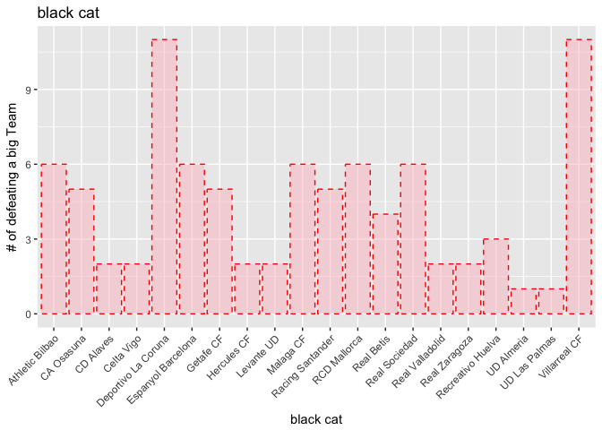

```r
p4=ggplot(a,aes(x=as.character(Opponent),y=numb))+geom_col(linetype = "dashed",color = "red",fill = "pink",alpha=0.5)+
  xlab("black cat")+ylab("# of defeating a big Team")+ggtitle("black cat")+theme(axis.text.x = element_text(angle = 45, hjust = 1, vjust = 1))
p4
```

۵. در تاریخ لالیگا کدام تیم رکورددار زودترین قهرمانی است؟ همچنین کدام تیم مقتدرانه ترین قهرمانی را داشته است؟

```r
#5


laliga_half%>%group_by(Season,GameTillNow)%>%arrange(scoreTillNow,goalDifTillNow)%>%
  mutate(rank=row_number(-scoreTillNow))->laliga2

full_join(
laliga2%>%filter(rank==1)%>%group_by(Season,GameTillNow)%>%
  select(Season,GameTillNow,team1 = Team , score1 = scoreTillNow),
laliga2%>%filter(rank==2)%>%group_by(Season,GameTillNow)%>%
  select(Season,GameTillNow,team2 = Team , score2 = scoreTillNow)  # همه ی رنک ۱و۲ ها در طول زمان هر فصل کنار همن
)%>%group_by(Season)%>%mutate(GameTillNowPercent=GameTillNow/max(GameTillNow)) ->d
```

```r
d%>%group_by(Season)%>%filter(((score1-score2)>3*(max(GameTillNow)-GameTillNow))&(GameTillNow!=max(GameTillNow)))%>%
  group_by(Season) %>% slice(which.min(GameTillNow)) -> stat

stat%>%arrange(GameTillNowPercent)%>%
  select(Season,Champion=team1,score1,runnersUp=team2,score2,GameTillNowPercent)%>%
  .[1:5,]->FastesChampions

FastesChampions%>%group_by(Champion)%>%summarise(percent=max(GameTillNowPercent))->FastesChampions2
FastesChampions2 %>%hchart(type = "bar",hcaes(x =Champion, y = percent),name = "")%>%
  hc_title(text = "black cat") %>% hc_yAxis(title = list(text = "when what percent of games were done"))
```

[interactive chart not shown]

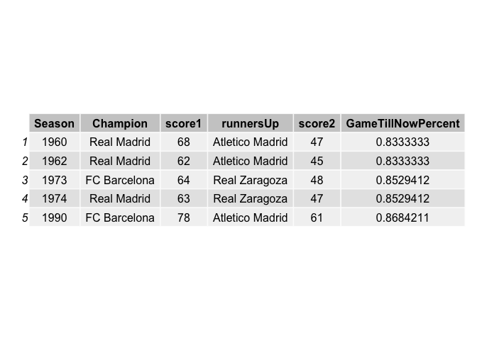

```r
p5=grid.table(FastesChampions)
```

```r
p5
```

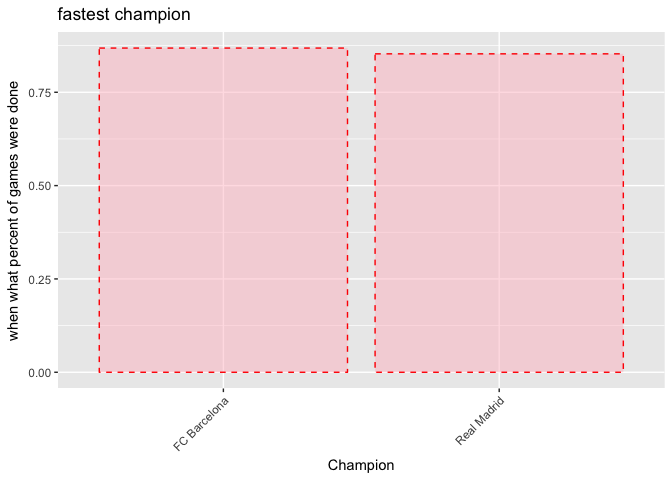

```r
p5_=ggplot(FastesChampions2,aes(x=Champion,y=percent))+geom_col(linetype = "dashed",color = "red",fill = "pink",alpha=0.5)+
  xlab("Champion")+ylab("when what percent of games were done")+
  ggtitle("fastest champion")+theme(axis.text.x = element_text(angle = 45, hjust = 1, vjust = 1))
p5_
```

```r
# 5 - 1

d %>%filter(GameTillNowPercent==1) %>% mutate(champdif=score1-score2) %>% arrange(-champdif) %>% .[1,]->bestChamp
writeLines(as.character(cat("best championship difference is for ",bestChamp$team1,"with",
                            bestChamp$champdif,"more score than 2nd team,",bestChamp$team2,"in ",bestChamp$Season ))
           , con = stdout(), sep = "\n", useBytes = FALSE)
```

```
## best championship difference is for  Real Madrid with 21 more score than 2nd team, Atletico Madrid in  1962
```

۶. طولانی ترین نوار پیروزی مساوی و شکست مال چه تیم هایی است؟

```r
# 6


rbind(
  fdb%>%
    select(Season,Date,Team=home,Opponent=visitor,Gt=hgoal,Go=vgoal),
  fdb%>%
    select(Season,Date,Team=visitor,Opponent=home,Gt=vgoal,Go=hgoal)
)%>%
  mutate(Gdif=Gt-Go)%>%
  mutate(W = (Gdif>0)
  ) %>% group_by(Team) %>%
  arrange(Date)%>%summarise(run_length = max(rle(W)$lengths[which(rle(W)$values== TRUE)])) %>%
  arrange(desc(run_length)) %>% .[1:2,] -> win_run

writeLines(as.character(cat("longest win run is for ",win_run$Team[1],"and",
                            win_run$Team[2]," with ",win_run$run_length[1]," wins " ))
           , con = stdout(), sep = "\n", useBytes = FALSE)
```

```
## longest win run is for  FC Barcelona and Real Madrid  with  16  wins
```

```r
rbind(
  fdb%>%
    select(Season,Date,Team=home,Opponent=visitor,Gt=hgoal,Go=vgoal),
  fdb%>%
    select(Season,Date,Team=visitor,Opponent=home,Gt=vgoal,Go=hgoal)
)%>%
  mutate(Gdif=Gt-Go)%>%
  mutate(W = (Gdif==0)
  ) %>% group_by(Team) %>%
  arrange(Date)%>%summarise(run_length = max(rle(W)$lengths[which(rle(W)$values== TRUE)])) %>%
  arrange(desc(run_length)) %>% .[1,]-> eq_run

writeLines(as.character(cat("longest drawn run is for ",eq_run$Team[1]," with ",eq_run$run_length[1]," Drawns" ))
           , con = stdout(), sep = "\n", useBytes = FALSE)
```

```
## longest drawn run is for  Burgos CF  with  9  Drawns
```